# Bicycle trips and relationships between them

# Investigation Overview

### In this investigation, I wanted to study the style of cycling and try to explore the relationships between its characteristics.

### The main focus was on the four Cs of the cycling trips: duration, Distance, speed,and the characteristics of members.

# Dataset Overview

# Distribution of The age of the members

### the age of the members in the dataset takes a kind of skewed to the right,the peak around age 30-40 where the most of the members age.

[figure not shown]

```python
## duration_min histogram
binsize = 10
bins = np.arange(0, bike['member_age'].max()+binsize, binsize)
plt.figure(figsize=[15, 5])
plt.hist(data = bike, x = 'member_age', bins = bins)
plt.xlabel('age of the members')
plt.xlim([16,100])##add xlim to clear the visual
plt.show();
```

# Distribution of the speed

### speed is calculated based on distance traveled and time taken, the distribution is normal, most of the members range in speed between 2 to 4 m/s.

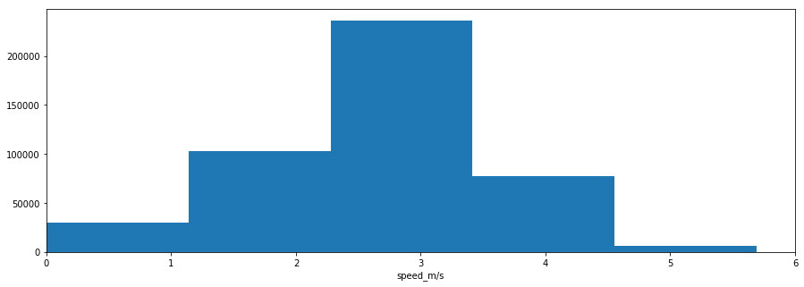

```python
plt.figure(figsize=[15, 5])
plt.hist(data = bike, x = 'speed_m/s')
plt.xlabel('speed_m/s')
plt.xlim([0,6])
plt.show();
```

# user type and the time of the day.

### the plot shows how many times the member started driving the bike at any time of the day, i can see that the most frequent time to start driving is "morning" for both subscriber and customer, maybe because this is the time to go to work.

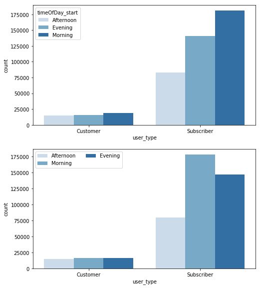

```python
plt.figure(figsize = [8, 15])
plt.subplot(3, 1, 1)
sb.countplot(data = bike,x='user_type',hue='timeOfDay_start', palette = 'Blues')
ax = plt.subplot(3, 1, 2)
sb.countplot(data = bike,x='user_type',hue ='timeOfDay_end',palette = 'Blues')
ax.legend(ncol = 2)
plt.show()
```

# The age of the member and the duration

### clearly there is no correlation between the age and the duration, so the age doesn't affect the duration of driving the bike.

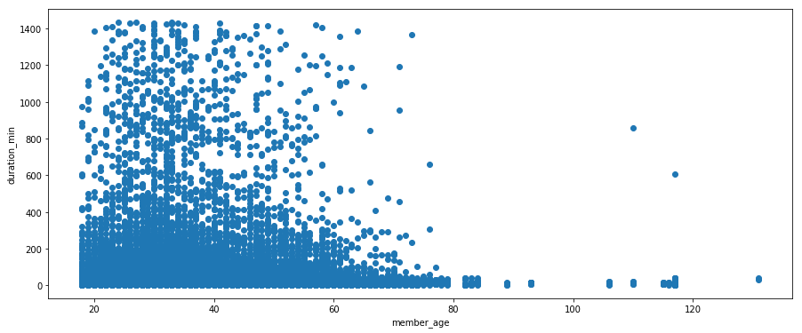

```python
plt.figure(figsize = [15, 6])
plt.scatter(data = bike, x = 'member_age', y = 'duration_min')
plt.xlabel('member_age')
plt.ylabel('duration_min')
plt.show();
```

# The Duration and the Distance by user type and the day of the week

### We can see how the duration increases on saturday and sunday whether the member subscriber or customer, and the distance decreases on saturday and sunday "weekend",perhaps because of the traffic.

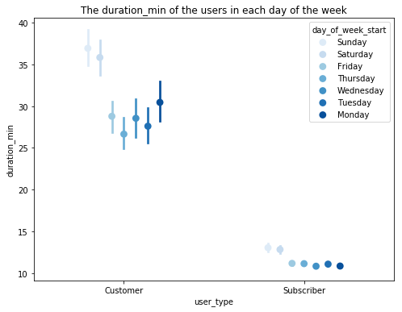

```python
fig = plt.figure(figsize = [8,6])
ax = sb.pointplot(data = bike, x = 'user_type', y = 'duration_min', hue = 'day_of_week_start',
           palette = 'Blues', linestyles = '', dodge = 0.4)
plt.title('The duration_min of the users in each day of the week')
plt.ylabel('duration_min')
ax.set_yticklabels([],minor = True)
plt.show();
#['member_gender', 'user_type', 'timeOfDay_start','day_of_week_start']
```

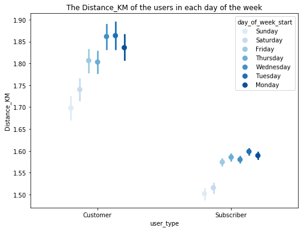

```python
fig = plt.figure(figsize = [8,6])
ax = sb.pointplot(data = bike, x = 'user_type', y = 'Distance_KM', hue = 'day_of_week_start',
           palette = 'Blues', linestyles = '', dodge = 0.4)
plt.title('The Distance_KM of the users in each day of the week')
plt.ylabel('Distance_KM')
ax.set_yticklabels([],minor = True)
plt.show();
```